# Uso de la programación lineal para la resolución de un modelo de flujos de cuota de mercado

**Francisco Espiga Fernández**

*Enero, 2022*

Más sobre ciencia de datos: [**cienciadedatos.net**](https://cienciadedatos.net)

En este artículo exploraremos el uso de modelos de programación lineal sobre los datos de partida de la cuota de mercado de un conjunto de competidores, para determinar los flujos individuales de captación de cuota entre ellos.

## Caso de negocio

En muchos contextos e industrias nos encontramos con un conjunto de productos o empresas que compiten entre ellas por la cuota de mercado. Ejemplos de esto podemos encontrarlos en:

- La cuota por provincia en Estaciones de Servicio en la industria de Oil&Gas, donde [CORES](https://www.cores.es/es/estadisticas) en España es una buena aproximación de ese *share*.
- Las audiencias de las distintas cadenas de televisión.
- El *share of wallet* de distintas marcas del consumidor y que recopilan empresas como [Kantar](https://www.kantarworldpanel.com/global/grocery-market-share/spain) o Statista.

Algo común en todos estos casos, es que, si bien conocemos el valor preciso o una estimación de estos *market share*, desconocemos el trasvase de cuota entre los distintos competidores, para cada instante de tiempo, así como las dinámicas que favorecen o dificultan dicho trasvase. En este artículo, recurriremos a los grafos como herramienta de visualización y a un modelo de programación lineal, o LP (*Linear Programming*).

Antes de seguir avanzando, debemos indicar al lector que para poder ejecutar correctamente el código del artículo, es necesario instalar la librería *pyomo* así como el solver *cbc* del proyecto [COIN-OR](https://www.coin-or.org/downloading/)

Para la librería, se puede instalar tanto via `pip` como desde `conda` independientemente de nuestro sistema operativo. Para el solver, dependiendo del sistema operativo, recomendamos:

- WINDOWS: descargar de la web del proyecto COIN-OR el solver, e indicar la ruta del ejecutable `pyo.SolverFactory('cbc', executable = 'path/to/solver/cbc.exe')`
- LINUX: instalación via conda mediante el comando `conda install -c conda-forge coincbc`

## Definiendo el problema

En el caso que nos ocupa, vamos a utilizar un modelo de programación lineal, que modelaremos usando la librería *pyomo* para determinar los flujos de trasvase de cuotas de mercado entre competidores y recurriremos a la librería *networkx* para la visualización de los datos en forma de grafo.

## Generación y visualización de los datos

```python
# Librerías
# ======================================================================================
import pandas as pd
import numpy as np
import matplotlib.pyplot as plt
from tqdm import tqdm
import networkx as nx
import pyomo.environ as pyo
from pyomo.core.base import Constraint
from pyomo.opt import SolverStatus, TerminationCondition
```

```python
#!conda install -c conda-forge coincbc
```

```python
# Generación de un escenario aleatorio
# ======================================================================================
n_competitors = 10
start_date = '2020-01-01'
end_date = '2021-01-01'
print(f"Generating random scenario from {start_date} to {end_date} with {n_competitors} competitors")

dates = [i.strftime('%Y-%m-%d') for i in pd.date_range(start_date, end_date, freq = 'M')]
CPs = [f"CP_{i}" for i in range(8)]

data = pd.DataFrame(np.random.uniform(0,100, [len(dates), len(CPs)]), index = dates, columns = CPs)
data_mktshare = data.div(data.sum(axis = 1).values, axis = 0)
data_delta_mktshare = data_mktshare.diff().fillna(value=0)
```

```
Generating random scenario from 2020-01-01 to 2021-01-01 with 10 competitors
```

Vamos a visualizar ahora la cuota de mercado de los competidores en un grafo, para un mes al azar.

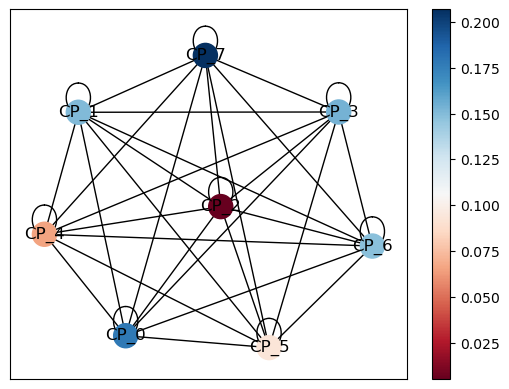

```python
# Gráfico del grafo
# ======================================================================================
timestamp = np.random.choice(data_mktshare.index, 1)[0]
attr = 'mkt_share'
edgelist = pd.DataFrame({'source':CPs}).merge(pd.DataFrame({'target':CPs}), how = 'cross')
G = nx.from_pandas_edgelist(edgelist, source='source', target='target')

nx.set_node_attributes(G, data_mktshare[data_mktshare.index == timestamp].reset_index(drop=True).T.to_dict()[0], attr)


COLOR_SCHEME = "RdBu"
colors = [G.nodes[node][attr] for node in list(G.nodes())]
nx.draw_networkx(G, node_color=colors, cmap=COLOR_SCHEME)#, vmin = -1, vmax = 1)

ax=plt.gca()
PCM=ax.get_children()[0]
plt.colorbar(PCM, ax=ax)
plt.show()
```

Verificamos como algunos de los competidores tienen un porcentaje muy elevado de cuota de mercado mientras que otros están un orden de magnitud por debajo, así como que todos nuestros datos son positivos y suman uno.

## Modelización

En primer lugar, tenemos que hacer una serie de asunciones y simplificaciones para nuestro problema.

### Asunciones

- El flujo entrante de cuota de mercado de un competidor, proviene del resto de competidores. En nuestro contexto parece trivial, pero por ejemplo en el financiero, podríamos intentar ver el flujo monetario entre distintos competidores, con una fuente de financiación externa en *cash*.
- Denominamos flujos de entrada o *inflows* a los flujos positivos, y de salida o *outflows* a los negativos.
- No puede haber bucles, es decir, flujos de entrada o salida de un competidor hacia sí mismo.

### Sets

Comenzamos por definir los distintos conjuntos de nuestro problema. En el contexto de la modelización y programación lineal, son los índices en los que indexaremos las distintas variables, parámetros y restricciones. En nuestro caso, tenemos los competidores $C$ y los meses $M$.

- $C$ : los competidores del mercado.
- $T$: los meses de histórico.

### Parámetros

Se denominan parámetros a aquellos valores que nos son conocidos de antemano y sobre cuyos valores no decidimos durante la optimización. En nuestro caso, tanto el *marketshare* de un competidor en un mes, como la evolución mes a mes del mismo.

- $\Delta Mk_{c,m}$: la evolución del marketshare entre el mes $m$ y el mes $m+1$ de un competidor $c$.
- $Mk_{c,m}$: el *marketshare* de un competidor en un mes dado.

### Variables de decisión

En este caso, nuestras variables de decisión van a ser los flujos de entrada o salida de cuota de mercado entre competidores. Podríamos adoptar la convención de un flujo único que pudiera ser tanto positivo ($Flow_{a\rightarrow b}$) si $b$ captura cuota de mercado a $a$, como negativo en caso contrario. Sin embargo, hemos optado por desdoblarlos para simplificar la redacción de algunas de las restricciones del modelo, y dotarlo de mayor flexibilidad en caso de querer expandirlo en un futuro.

- $\forall m \in T, c_1 \in C, c_2 \in C: OutFlow_{m,c_1,c_2} \in R^+$: flujo negativo de cuota de mercado entre competidores.
- $\forall m \in T, c_1 \in C, c_2 \in C: InFlow_{m,c_1,c_2} \in R^+$: flujo positivo de cuota de mercado entre competidores.

### Consideraciones adicionales

#### Formato de los datos de entrada

Para inicializar los valores de los parámetros en pyomo, necesitamos tener los datos en formato largo, con las columnas índice (competidores y meses) y la columna valor. Esto lo usaremos para declarar un diccionario con claves las tuplas de los índices y valor el valor del parámetro que queremos inicializar, o bien filtrar la fila deseada del dataframe.

```python
data_long_delta_mktshare = (
    data_delta_mktshare
    .reset_index()
    .melt(id_vars='index')
    .rename(columns={'variable':'CP', 'value':'delta_mkt_share', 'index':'timestamp'})
)

data_long_mktshare = (
    data_mktshare
    .reset_index()
    .melt(id_vars='index')
    .rename(columns={'variable':'CP', 'value':'mkt_share', 'index':'timestamp'})
)

data_long_mktshare.head()
```

|  | timestamp | CP | mkt_share |
| --- | --- | --- | --- |
| 0 | 2020-01-31 | CP_0 | 0.246785 |
| 1 | 2020-02-29 | CP_0 | 0.191869 |
| 2 | 2020-03-31 | CP_0 | 0.131337 |
| 3 | 2020-04-30 | CP_0 | 0.029125 |
| 4 | 2020-05-31 | CP_0 | 0.085638 |

#### Variables de holgura

Añadimos dos variables de holguras, *vPositiveSlack* y *vNegativeSlack* para facilitar el determinar los flujos. En nuestro caso de programación lineal, puede que algunas restricciones, como la de simetría (el flujo de salida de $B$ a $A$ es igual al de entrada desde $B$ a $A$, cambiado de signo) puede que no sean exactamente iguales, sino con tolerancias cercanas al cero. En caso de no ser idénticos, esto haría que nuestro problema no encontrase una solución que respetase todas las restricciones, es decir, que fuese factible.

Al recurrir a las holguras, damos cierto "margen" para poder cumplir las restricciones, y dotamos al problema de flexibilidad en caso de expandirlo en el futuro con relaciones y dependencias más complejas, pero garantizando que exista una solución factible. Sin embargo, es necesario que penalicemos el uso de estas variables de holgura, ya que si no, nuestro problema no tendría ningún incentivo en respetar las restricciones. Esto lo lograremos en la función objetivo.

#### Restricciones implícitas en el procesamiento de datos

En nuestros datos generados, así como en un contexto que utilice datos reales, existen dos restricciones de manera implícita que no necesitamos indicar en el modelo. Por un lado, que la suma de las cuotas de mercado entre todos los competidores sea del 100% (sume 1) y, por otro lado, que la suma de las evoluciones de las cuotas de mercado ($\Delta Mk$) sea nulo.

- CTa: Cálculo del delta marketshare: $$\forall c\in C, m\in T-\{M_0\}:\Delta Mk_{z,t} = Mk_{c,m}-Mk_{c, m-1}$$
- CTb: Ecuación de equilibrio de la cuotrra de mercado: $$\forall m\in T: \sum_c Mk_{c,m} == 1$$

```python
# Optimización del modelo
# ======================================================================================

model = pyo.ConcreteModel()

# Sets ----
model.sCP = pyo.Set(initialize = CPs)
model.sTimestamps = pyo.Set(initialize = dates)

# Parameters ----
def get_mktshare_delta(model, p, m):
    return data_long_delta_mktshare[(data_long_delta_mktshare.CP == p) & (data_long_delta_mktshare.timestamp == m)]['delta_mkt_share'].values[0]

model.pDeltaMktShare = pyo.Param(model.sCP, model.sTimestamps, initialize = get_mktshare_delta)

def get_mktshare(model, p, m):
    return data_long_mktshare[(data_long_mktshare.CP == p) & (data_long_mktshare.timestamp == m)]['mkt_share'].values[0]

model.pMktShare = pyo.Param(model.sCP, model.sTimestamps, initialize = get_mktshare)

# Variables ----
"""
Outflow A,B es lo que el nodo B transfiere al nodo A.
Inflow A,B es lo que el nodo A toma del nodo B.
Por tanto: Outflow A,B = -Inflow B,A

Para un nodo: la variación de marketshare es la suma de los outflows (A, x): todo lo que se toma de los nodos; y los inflows (A, y) que es recibido por parte de los demás nodos.
"""
model.vOutFlow = pyo.Var(model.sCP, model.sCP, model.sTimestamps, within = pyo.NonPositiveReals) # Negativo para flujos de salida.
model.vInFlow = pyo.Var(model.sCP, model.sCP, model.sTimestamps, within = pyo.NonNegativeReals) # Positivo para flujos entrantes.
model.vPositiveSlack = pyo.Var(model.sCP, model.sCP, model.sTimestamps, within = pyo.NonNegativeReals, bounds=(0,0.05))
model.vNegativeSlack = pyo.Var(model.sCP, model.sCP, model.sTimestamps, within = pyo.NonPositiveReals, bounds=(-0.05,0))
```

### Restricciones

#### CT1: Market delta flows

La variación del *marketshare* en un mes dado es la suma de los flujos de entrada y de salida respecto del resto de competidores.

$$\forall c\in C, t\in T:\Delta M_{c,t} = \sum_{y\in C-\{c\}} OutFlow_{t,y,c} + InFlow_{t,y,c} $$

```python
## CT1: el delta de marketshare debe ser la suma de inflows (>=0) y outflows (<=0)
## Añadimos el slack u holgura para facilitar encontrar una solución factible. Nuestro objetivo será minimizarlo.
def mktshare_equilibrium(model, p, t):
    return model.pDeltaMktShare[p, t]==sum(model.vOutFlow[p, p_x, t] + model.vInFlow[p, p_x, t] + model.vPositiveSlack[p,p_x, t] + model.vNegativeSlack[p,p_x, t] for p_x in model.sCP)

model.ctMktShareEquilibrium = pyo.Constraint(model.sCP, model.sTimestamps, rule = mktshare_equilibrium)
```

#### CT2: Out/In flow balance:

El flujo de entrada de A desde B, es el negativo del flujo de salida de B hacia A. $$\forall t \in T, z_1 \in Z, z_2 \in Z: OutFlow_{t,z_1,z_2}==InFlow_{t,z_2,z_1}$$

```python
## CT2: Simetría Outflow (A,B) e Inflow (B,A), cambiando el signo.
def connect_flows(model, p_a, p_b, t):
    return model.vOutFlow[p_a, p_b, t]==-model.vInFlow[p_b, p_a, t]
model.ctFlowConnection = pyo.Constraint(model.sCP, model.sCP, model.sTimestamps, rule = connect_flows)
```

#### CT3: Evitar bucles

- CT3a: salida: $$\forall t \in T, z_1 \in Z, z_1 \in Z: OutFlow_{t,z_1,z_1}=0$$
- CT3b: entrada: $$\forall t \in T, z_1 \in Z, z_1 \in Z: InFlow_{t,z_1,z_1}=0$$

```python
## CT3: Evitar bucles de entrada y de salida
def outflow_loops(model, p, t):
    return model.vOutFlow[p, p, t]==0

model.ctBlockOutflowLoops = pyo.Constraint(model.sCP, model.sTimestamps, rule = outflow_loops)

def inflow_loops(model, p, t):
    return model.vInFlow[p, p, t]==0

model.ctBlockInflowLoops = pyo.Constraint(model.sCP, model.sTimestamps, rule = inflow_loops)
```

#### CT4: limitar los flujos de salida

Los flujos de salida de un competidor hacia el resto, siempre deben ser menores que el marketshare del mes previo. $$\forall t \in T, z_1 \in Z, z_2 \in Z: OutFlow_{t,z_1,z_2}<=MktShare_{t-1, z_1}$$

```python
## CT4: La suma de flujos de salida debe ser siempre inferior al marketshare precedente.
def sum_of_outflows(model, p, t):
    if t == model.sTimestamps.first():
        return Constraint.Skip
    else:
        return -(sum(model.vOutFlow[p, p_x, t] for p_x in model.sCP))<=model.pMktShare[p, model.sTimestamps.prev(t)]

model.ctMaxOutflows = pyo.Constraint(model.sCP, model.sTimestamps, rule = sum_of_outflows)
```

#### CT5: unicidad de los flujos de entrada y de salida

En nuestro contexto de negocio, no tendría sentido que un competidor A capture cuota de mercado de un competidor B, y que el competidor B capture cuota de mercado del competidor A. Podríamos argumentar en contra, que si por ejemplo el trasvase de cuota de mercado obedece a criterios económicos por un lado; y por otro a la presencia en RRSS, publicidad en medios, etc, podría darse el caso de que un competidor A captura "económicamente" cuota de B, y éste "por publicidad", cuota de A. No obstante, en nuestro caso mantenemos un enfoque simple de flujos de entrada o de salida en términos netos, por lo que no se puede dar esta situación.

Recordemos que los flujos de entrada o *inflows* tienen el signo positivo, y los *outflows* o de salida, negativos. En este caso, podemos restringir esa unicidad de los flujos del siguiente modo:

- Para los inflows: $Inflow_{a,b}+Inflow_{b,a}=max(Inflow_{a,b},Inflow_{b,a})$
- Para los outflows: $Outflow_{a,b}+Outflow_{b,a}=min(Outflow_{a,b},Outflow_{b,a})$

No obstante, tanto el máximo como el mínimo no son funciones lineales, pero las podemos modelar mediante el uso de variables binarias y restricciones de tipo "big M". Explicamos el caso de los *outflows* en detalle, aunque para los inflows será análogo.

- El mínimo siempre será $\leq$ que ambos flujos de salida, al ser el más negativo de los dos.

$$Minimum\;outflow_{t, a, b}= Min(Outflow_{t,a,b}, Outflow_{t,b,a})$$$$Minimum\;outflow_{t, a, b}<= Outflow_{t,a,b}$$$$Minimum\;outflow_{t, a, b}<= Outflow_{t,b,a}$$

- Por otro lado reforzamos que la suma de ambos tenga que ser igual al mínimo, de manera simétrica.

$$Minimum\;outflow_{t, a, b}== Outflow_{t,a,b} + Outflow_{t,b,a}$$

$$Minimum\;outflow_{t, a, b}==Minimum\;outflow_{t, b, a}$$

$$X<=x1$$$$X<=x2$$$$X>=x1-M(1-y)$$$$X>=x2-My$$

Las dos primeras restricciones son las anteriormente mencionadas. Las dos siguientes, con el uso de la constante M y la variable binaria indicativa *y*, fuerzan que solo uno de los valores pueda tomar un valor distinto de cero.

```python
M = 1e2

## CT5: bien hay un flujo de salida de A a B o bien de B a A.
"""
No podemos tener flujos de salida o de entrada de A a B y de B a A simultáneamente. O bien uno transfiere (recibe) o bien el otro.
Esto es lo mismo matemáticamente que decir:
- La suma de outflows es igual al outflow minimo.
- La sunma de inflows es igual al inflow maximo.

    x2-x1 = My
    x1-x2 = M(1-y)
    X<=x1
    X<=x2
    X>=x1-M(1-y)
    X>=x2-My
"""
### El mínimo outflow es la suma de los outflows.
### ref: https://or.stackexchange.com/questions/1160/how-to-linearize-min-function-as-a-constraint
model.vMinOutflow = pyo.Var(model.sCP, model.sCP, model.sTimestamps, within = pyo.NonPositiveReals)
model.vbMinOutflowFlag = pyo.Var(model.sCP, model.sCP, model.sTimestamps, within = pyo.Binary)

model.ctOneOutflow = pyo.ConstraintList()
for p_a in model.sCP:
    for p_b in model.sCP:
        for t in model.sTimestamps:
            #model.ctOneOutflow.add(expr = model.vOutFlow[p_b, p_a, t]-model.vOutFlow[p_a, p_b, t] == M*model.vbMinOutflowFlag[p_a, p_b, t])
            #model.ctOneOutflow.add(expr = model.vOutFlow[p_a, p_b, t]-model.vOutFlow[p_b, p_a, t] == M*(1-model.vbMinOutflowFlag[p_a, p_b, t]))

            model.ctOneOutflow.add(expr = model.vMinOutflow[p_a, p_b, t] <= model.vOutFlow[p_a, p_b, t])
            model.ctOneOutflow.add(expr = model.vMinOutflow[p_a, p_b, t] <= model.vOutFlow[p_b, p_a, t])

            model.ctOneOutflow.add(expr = model.vMinOutflow[p_a, p_b, t] >= model.vOutFlow[p_a, p_b, t]-M*(1-model.vbMinOutflowFlag[p_a, p_b, t]))
            model.ctOneOutflow.add(expr = model.vMinOutflow[p_a, p_b, t] >= model.vOutFlow[p_b, p_a, t]-M*(model.vbMinOutflowFlag[p_a, p_b, t]))

            model.ctOneOutflow.add(expr = model.vOutFlow[p_b, p_a, t]+model.vOutFlow[p_a, p_b, t] == model.vMinOutflow[p_a, p_b, t])
            model.ctOneOutflow.add(expr = model.vMinOutflow[p_b, p_a, t] == model.vMinOutflow[p_a, p_b, t])


### El máximo outflow es la suma de los outflows.
### ref: https://math.stackexchange.com/questions/2446606/linear-programming-set-a-variable-the-max-between-two-another-variables
model.vMaxInflow = pyo.Var(model.sCP, model.sCP, model.sTimestamps, within = pyo.NonNegativeReals)
model.vbMaxInflowFlag = pyo.Var(model.sCP, model.sCP, model.sTimestamps, within = pyo.Binary)

model.ctOneInflow = pyo.ConstraintList()
for p_a in model.sCP:
    for p_b in model.sCP:
        for t in model.sTimestamps:
            model.ctOneInflow.add(expr = model.vMaxInflow[p_a, p_b, t] >= model.vInFlow[p_a, p_b, t])
            model.ctOneInflow.add(expr = model.vMaxInflow[p_a, p_b, t] >= model.vInFlow[p_b, p_a, t])

            model.ctOneInflow.add(expr = model.vMaxInflow[p_a, p_b, t] <= model.vInFlow[p_a, p_b, t] + M*model.vbMaxInflowFlag[p_a, p_b, t])
            model.ctOneInflow.add(expr = model.vMaxInflow[p_a, p_b, t] <= model.vInFlow[p_b, p_a, t] + M*(1-model.vbMaxInflowFlag[p_a, p_b, t]))

            model.ctOneInflow.add(expr = model.vInFlow[p_b, p_a, t]+model.vInFlow[p_a, p_b, t] == model.vMaxInflow[p_a, p_b, t])
            model.ctOneInflow.add(expr = model.vMaxInflow[p_b, p_a, t] == model.vMaxInflow[p_a, p_b, t])
```

#### CT6: restricción de inicialización de los flujos en T_0

Como última restricción, obligamos a que los flujos de entrada y salida para todos los competidores en el instante 0, deban ser nulos. Esto garantizará también el cumplimiento de las restricciones de máximo / mínimo anteriormente formuladas

$$\forall c_1 \in C, c_2 \in C: InFlow_{\;0,c_1,c_2}=0$$$$\forall c_1 \in C, c_2 \in C: OutFlow_{\;0,c_1,c_2}=0$$

```python
## CT6: Los flujos en T=0 son nulos.
def zero_inflows(model, p_a, p_b):
    return model.vInFlow[p_a, p_b, model.sTimestamps.first()] ==0
model.ctZeroInitialInFlows = pyo.Constraint(model.sCP, model.sCP, rule = zero_inflows)

def zero_outflows(model, p_a, p_b):
    return model.vOutFlow[p_a, p_b, model.sTimestamps.first()] ==0
model.ctZeroInitialOutFlows = pyo.Constraint(model.sCP, model.sCP, rule = zero_outflows)
```

#### Función objetivo

Por último, nuestra función objetivo no es trivial. Aunque el caso que nos ocupa, al querer repercutir las variaciones de cuota de mercado a flujos de entrada y salida a competidores, podría formularse como un problema de satisfacción de restricciones, nosotros hemos añadido las variables de holgura o *slacks* para facilitar el encontrar una solución factible y tener flexibilidad de cara a modificaciones ulteriores. Por tanto, nuestra función objetivo será la suma de las holguras positivas, menos la suma de las holguras negativas, que buscaremos minimizar.

$$min z = \sum_{t, z_1, z_2} slack^+_{t, z_1,z_2} - \sum_{t, z_1, z_2} slack^-_{t, z_1,z_2}$$

```python
# Función objetivo
minimize = 1
model.Z = pyo.Objective(sense = minimize, expr = sum(
    model.vPositiveSlack[p_a,p_b,t] for p_a in model.sCP for p_b in model.sCP for t in model.sTimestamps)-sum(
    model.vNegativeSlack[p_a,p_b,t] for p_a in model.sCP for p_b in model.sCP for t in model.sTimestamps))
```

### Solucionando el modelo e inspeccionando los resultados

Una vez concluida la fase de modelado, podemos proceder a resolverlo y analizar y visualizar los resultados. En este caso, usaremos el solver cbc del proyecto COIN-OR, un solver lineal y open source. Como alternativas gratuitas a éste, SCIP recientemente ha sido disponibilizado tanto para entornos académicos como para profesionales sin necesidad de licenciamiento.

```python
solver = pyo.SolverFactory('cbc')

solution_status =  solver.solve(model)
solution_status
```

```
{'Problem': [{'Name': 'unknown', 'Lower bound': 0.0, 'Upper bound': 0.0, 'Number of objectives': 1, 'Number of constraints': 4489, 'Number of variables': 3314, 'Number of nonzeros': 850, 'Sense': 'minimize'}], 'Solver': [{'Status': 'ok', 'User time': -1.0, 'System time': 1.13, 'Wallclock time': 1.13…
```

El modelo es capaz de encontrar rápidamente una solución factible y óptima. Uno de los mayores desafíos en el ámbito de la programación lineal, y que hace que en entornos industriales debamos decantarnos a favor de solvers comerciales, es su capacidad para encontrar rápidamente (en términos relativos) soluciones que sean factibles, sobre las que poder continuar la exploración de cara a encontrar una óptima. En las ocasiones en que utilicemos un solver open source, y experimentemos largos tiempos de resolución que no logran encontrar una solución, o cuyo resultado sea el de infactibilidad, puede resultar conveniente el uso de dichos solvers comerciales, ya que ellos sí que pueden ser capaces de encontrarla, o de arrojar el resultado de la infactibilidad con mayor rapidez.

```python
def prepare_inflows(model, exclude_zeros:bool = True):
    inflows = pd.DataFrame.from_dict(model.vInFlow.extract_values(), orient = 'index').reset_index()
    if exclude_zeros:
        inflows = inflows[inflows[0]>0]

    inflows[['cp_a', 'cp_b', 'timestamp']] = pd.DataFrame(inflows['index'].tolist(), index=inflows.index)
    inflows = inflows.drop('index', axis = 1).rename(columns = {0:'inflow', 'cp_a':'target', 'cp_b':'source'})
    return inflows

def prepare_outflows(model, exclude_zeros:bool = True):
    outflows = pd.DataFrame.from_dict(model.vOutFlow.extract_values(), orient = 'index').reset_index()
    if exclude_zeros:
        outflows = outflows[outflows[0]<0]

    outflows[['cp_a', 'cp_b', 'timestamp']] = pd.DataFrame(outflows['index'].tolist(), index=outflows.index)
    outflows = outflows.drop('index', axis = 1).rename(columns = {0:'outflow', 'cp_a':'source', 'cp_b':'target'})
    return outflows

def create_graph(model, attr:str = 'mkt_share', timestamp:str = None):
    if timestamp is None:
        timestamp = np.random.choice(data_mktshare.index, 1)[0]

    edgelist = pd.DataFrame({'source':CPs}).merge(pd.DataFrame({'target':CPs}), how = 'cross')
    G = nx.from_pandas_edgelist(edgelist, source='source', target='target')

    assert attr in ['mkt_share', 'mkt_share_delta', 'inflow', 'outflow']
    if attr == 'mkt_share':
        nx.set_node_attributes(G, data_mktshare[data_mktshare.index == timestamp].reset_index(drop=True).T.to_dict()[0], attr)
    elif attr == 'mkt_share_delta':
        nx.set_node_attributes(G, data_delta_mktshare[data_delta_mktshare.index == timestamp].reset_index(drop=True).T.to_dict()[0], attr)
    elif attr in ['inflow', 'outflow']:
        nx.set_node_attributes(G, data_delta_mktshare[data_delta_mktshare.index == timestamp].reset_index(drop=True).T.to_dict()[0], 'mkt_share_delta')
        if attr == 'inflow':
            vals = prepare_inflows(model)
        elif attr == 'outflow':
            vals = prepare_outflows(model)

        vals = vals[vals.timestamp == timestamp].drop('timestamp', axis = 1)
        kvals = list(vals.loc[:,['source','target']].itertuples(index=False, name=None))
        vvals = vals[attr].values.tolist()
        nx.set_edge_attributes(G, dict(zip(kvals, vvals)), attr)

    COLOR_SCHEME = "RdBu"
    colors = [G.nodes[node]['mkt_share_delta' if attr in ['inflow', 'outflow'] else attr] for node in list(G.nodes())]
    if attr in ['inflow', 'outflow']:
        norm = plt.Normalize()
        edge_attr = nx.get_edge_attributes(G, attr)
        edge_colors = plt.cm.RdBu(norm(list(edge_attr.values())))

        nx.draw_networkx(G, node_color=colors, cmap=COLOR_SCHEME, edge_color = edge_colors)#, edges = list(edge_attr.keys()))

    else:
        nx.draw_networkx(G, node_color=colors, cmap=COLOR_SCHEME)#, vmin = -1, vmax = 1)

    ax=plt.gca()
    PCM=ax.get_children()[0]
    plt.colorbar(PCM, ax=ax)
    plt.show()
    return vals
```

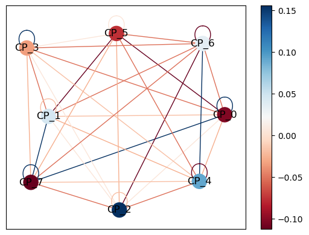

|  | inflow | target | source |
| --- | --- | --- | --- |
| 183 | 0.044975 | CP_1 | CP_7 |
| 195 | 0.102212 | CP_2 | CP_0 |
| 279 | 0.052960 | CP_2 | CP_7 |
| 423 | 0.033938 | CP_4 | CP_3 |
| 447 | 0.042164 | CP_4 | CP_5 |
| 471 | 0.014331 | CP_4 | CP_7 |
| 639 | 0.034018 | CP_6 | CP_5 |

```python
create_graph(model, 'inflow')
```

## Conclusiones

En este artículo hemos explorado cómo asignar los flujos de cuota de mercado trasvasados entre distintos competidores, mediante un modelo de programación lineal escrito con *pyomo* y que hemos resuelto con solvers open source, y cuyos resultados hemos visualizado en forma de grafo recurriendo a la librería *networkx*.

En lo referente al modelado, además de variables, conjuntos y restricciones habituales en la literatura de la programación lineal, hemos usado restricciones de tipo big M así como una linealización de las restricciones de mínimo y máximo para los flujos de entrada y de salida. Como siguientes pasos, podríamos destacar que una vez determinados dichos flujos de trasvase de cuota de mercado, podríamos expandir nuestro modelo, para repercutirlo a parámetros como el diferencial económico entre los distintos competidores, acciones de mercado o percepción en plataformas como RRSS.

## Información de sesión

```python
import session_info
```

```python
session_info.show(html=False)
```

```
-----
matplotlib          3.6.2
networkx            3.0
numpy               1.23.4
pandas              1.4.4
pyomo               6.4.4
session_info        1.0.0
tqdm                4.64.1
-----
IPython             8.6.0
jupyter_client      7.4.7
jupyter_core        5.2.0
jupyterlab          3.3.4
notebook            6.5.2
-----
Python 3.8.15 (default, Nov  4 2022, 15:16:59) [MSC v.1916 64 bit (AMD64)]
Windows-10-10.0.19044-SP0
-----
Session information updated at 2023-01-31 20:33
```

## Bibliografía

**¿Cómo citar este documento?**

Uso de la programación lineal para la resolución de un modelo de flujos de cuota de mercado by Francisco Espiga, available under a CC BY-NC-SA 4.0 at https://www.cienciadedatos.net/documentos/py47-uso-programacion-lineal-flujos-marketshare.html

**¿Te ha gustado el artículo? Tu ayuda es importante**

Mantener un sitio web tiene unos costes elevados, tu contribución me ayudará a seguir generando contenido divulgativo gratuito. ¡Muchísimas gracias! 😊